# Bolas_Lab10 Interpolation

Ellie Bolas, GEO200CN, spring 2017

# Lab 10: Interpolation

In this lab you will work with two California datasets, one measuring precipitation across the state, and a second measuring air quality, including ozone rates. This lab provides an opportunity to practice and compare various interpolation methods, and continue to strengthen your familiarity with R.

Read and follow along with the Interpolations chapter at RSpatial respond to the 10 in-text questions, and complete the optional bonus assignment on the lab sheet. [http://rspatial.org/analysis/rst/4-interpolation.html]

Upload to smartsite an Rmarkdown and HTML file.

Due: Wednesday, May 17, 9a

# Interpolation

Spatial autocorrelation in spatial data is helpful if we want to predict values at locations where no measurements have been made. We are relying on Tobler’s 1st law here, that near things are more related than distance things.

### Exact Interpolation

In exact interpolation, the height of the surface (field), z, is described based on known points, such that the surface is true at each of these control points. 3 major techniques are used to automate interpolation: -proximity polygons -local spatial average -inverse distance weighted spatial average

The problem with these interpolations is that the don’t recognize variability over space and time or error. Also, they don’t take into account spatial behavior.

### Statistical Interpolations:

Trend surface analysis generalizes the field into a major feature or trend. This is an extension of multiple linear regression and uses the ordinary least squaures regression to approximate a trend in z.

Kriging uses the distance weighting technique by using control points to find optimum values for the weights of the data values. Based on the spatial variation shown in semivariogram (squared height difference x distance between spot heights), a function is selected to fit/model the data. The the model is used to determine weights.

### read in data

```r
datapath <-"C:/Users/ebola/Google Drive/Git/GEO200CN/data"

d <- read.csv(file.path(datapath, "precipitation.csv"))
#head(d)
```

### Annual Precipitation in CA- graph, map, and transformed coordinates

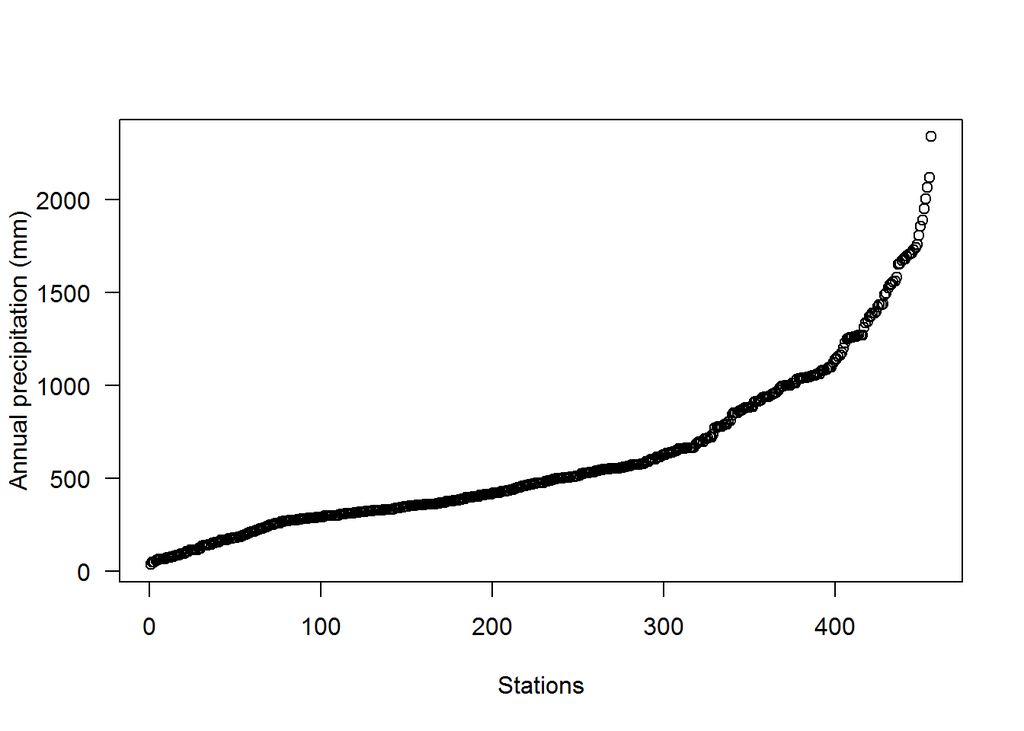

```r
d$prec <- rowSums(d[, c(6:17)]) #make a total precip column for every row

##graph by ascending precip
plot(sort(d$prec), ylab='Annual precipitation (mm)', las=1, xlab='Stations')


##map of precip, will use spspoly which is a way of plotting spatial data
library(sp)
```

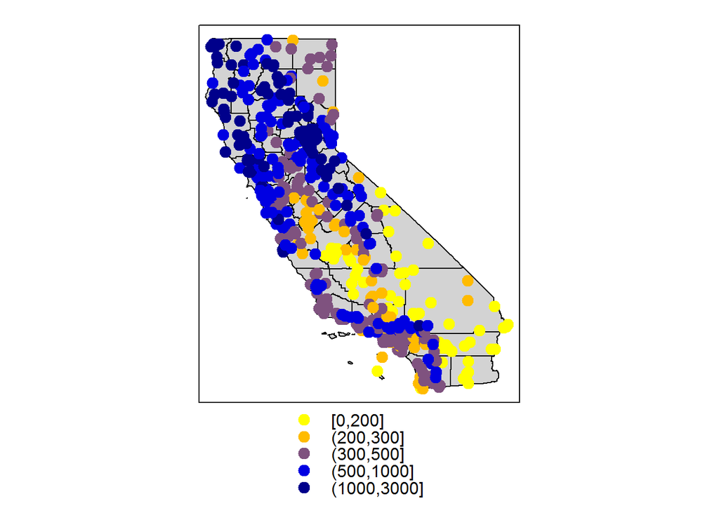

```r
#make spatialpoints of lon and lat, add NAD83 projection
dsp <- SpatialPoints(d[,4:3], proj4string=CRS("+proj=longlat +datum=NAD83"))

#make spatial points df with lon lat and d data
dsp <- SpatialPointsDataFrame(dsp, d)
#head(dsp)
CA <- readRDS(file.path(datapath, "counties.rds"))

# define groups for mapping
cuts <- c(0,200,300,500,1000,3000)

# set up a palette of interpolated colors, one color for each zone
blues <- colorRampPalette(c('yellow', 'orange', 'blue', 'dark blue'))

#set up the polygons to be mapped using spplot
pols <- list("sp.polygons", CA, fill = "lightgray")

spplot(dsp, 'prec', cuts=cuts, col.regions=blues(5), sp.layout=pols, pch=20, cex=2)
```

```r
##Transform coordinates using the commonly used coordinate reference system for California (“Teale Albers”)

#assign a projection to a variable
TA <- CRS("+proj=aea +lat_1=34 +lat_2=40.5 +lat_0=0 +lon_0=-120 +x_0=0 +y_0=-4000000 +datum=NAD83 +units=m +ellps=GRS80 +towgs84=0,0,0")

library(rgdal)
#transform the points
dta <- spTransform(dsp, TA)
cata <- spTransform(CA, TA)
#head(dta)
```

# Exact Interpolation

## Null Model

To interpolate precip for unsampled locations, make a null-model using a mean of all observations. Use the Root Mean Square Error statistic. RMSE = differences between observed and predicted values. Looking at the error at each point.

```r
#for each data point, observed-predicted = residual error, square it to make the data positive, take the mean of all of them the the square root to smooth it, pull in outliers. RMSE is a way of comparing real data against a null model

RMSE <- function(observed, predicted) {
  sqrt(mean((predicted - observed)^2, na.rm=TRUE))
}

#observed= dsp$precip, expected is the means of dsp$precip
null <- RMSE(dsp$prec, mean(dsp$prec))


null #435.3217
```

```
## [1] 435.3217
```

## Proximity Polygons/Nearest Neighbor Interpolation

Used to interpolate categorial variables. Every unsampled point gets the value of its nearest control point. Assumes each polygon has a uniform height equal to the height at the control point.

```r
library(dismo)
#Voronoi create voronoi or thiessen or nearest neighbor polygons.
#dta is dsp, our spatialpoints df with all our info, but the coorindates were transformed
v <- voronoi(dta)
```

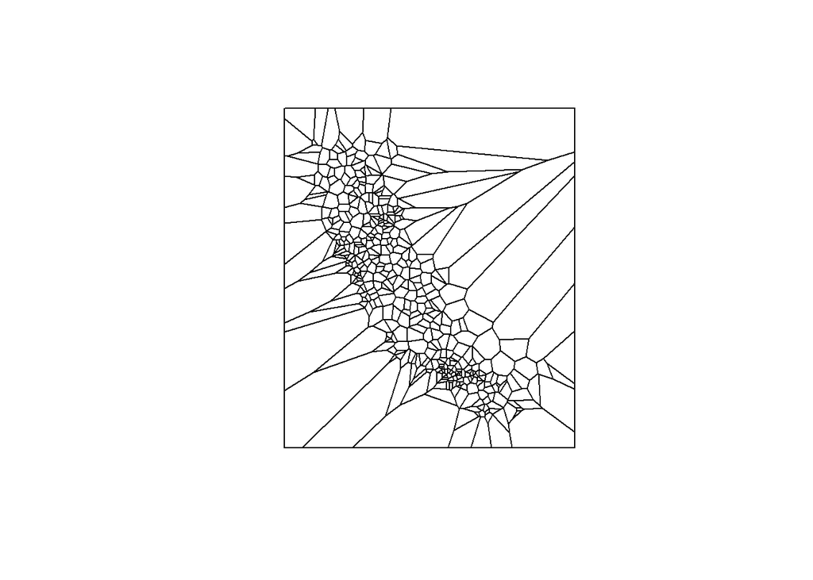

```r
plot(v)
```

```r
#confine this to CA
#cata is CA counties with coordinates transformed
ca <- aggregate(cata) #cata is california counties
class(ca) #spatial polygons
```

```
## [1] "SpatialPolygons"
## attr(,"package")
## [1] "sp"
```

```r
class(v) #spatial polygons df
```

```
## [1] "SpatialPolygonsDataFrame"
## attr(,"package")
## [1] "sp"
```

```r
vca <- intersect(v, ca) #makes new spatialpolygons combining the voroni polygons of dta with the polgons of the counties
class(vca) #spatial polygons df
```

```
## [1] "SpatialPolygonsDataFrame"
## attr(,"package")
## [1] "sp"
```

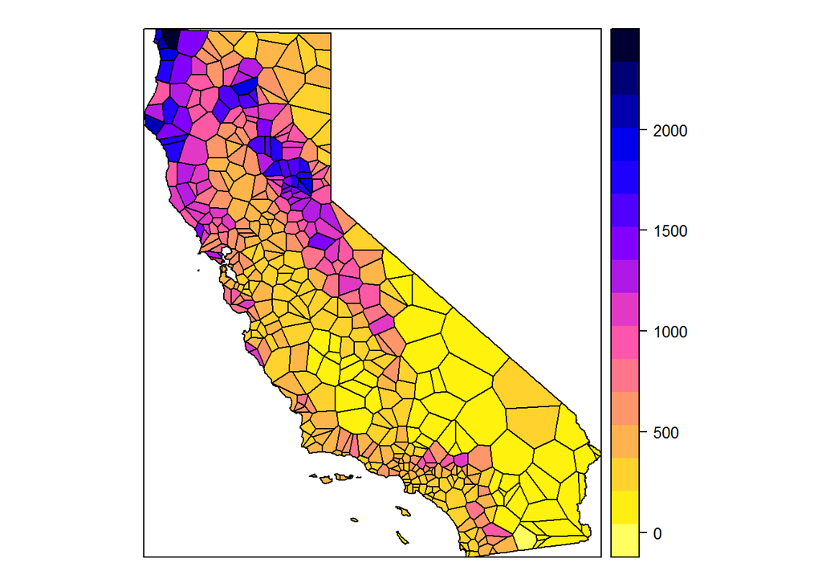

```r
#plot polygons by precip
spplot(vca, 'prec', col.regions=rev(get_col_regions()))
```

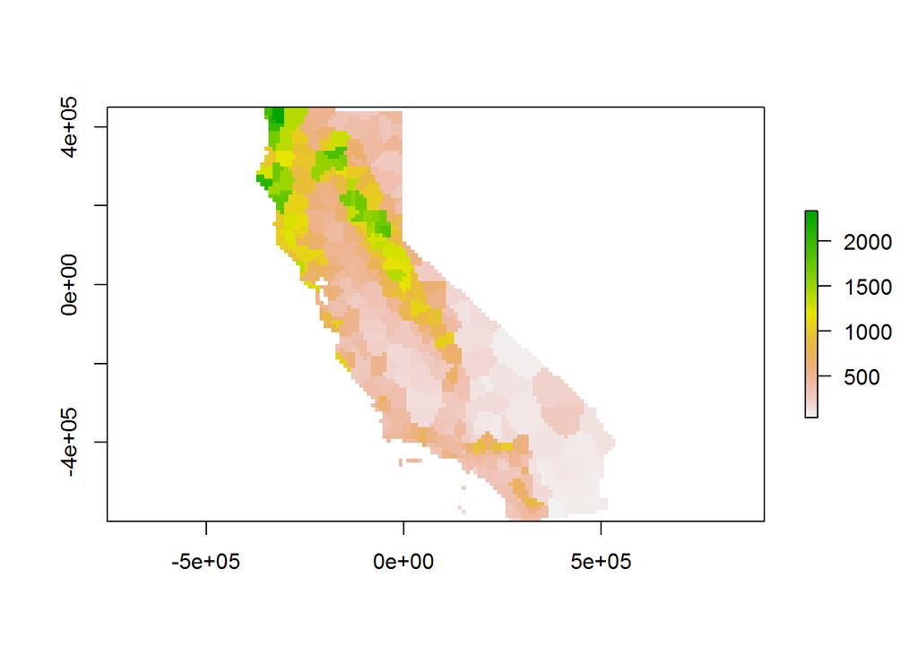

```r
#rasterize this
r <- raster(cata, res=10000)

#to rasterize, 1st argument is the spatial polygons object, 2nd argument is the raster object, "precip" is field, the values to be transfered. in other words, the column name of the variable we want to transfer
vr <- rasterize(vca, r, 'prec') #raster of voroni polygons of precip data fitted to CA counties
plot(vr)
```

### 5-fold Cross Validation

training data vs. test data. Checking the proximity polygons for significance.

#### Question 1: Describe what each step in the code chunk above does

Answered inline with code

```r
set.seed(5132015) #random number generator. this means that the way the k groups will be randomly assigned will happen the same way each time. For each bin of the kfold, it makes sure that dta is randomly placed in that bin in the same way, each time.

#kfold partitioning is for testing of models. Each record in the matrix is randomly assigned a group between 1-k. k will be defined in the for loop.  for each round of k, a certain amount of data will be the training data, and then some test data will be compared against it.

#here, use the number of rows in dta, the dsp transformed.
#dta is a dataframe with long/lat monthly precip and average precip for places around CA
kf <- kfold(nrow(dta))

rmse <- rep(NA, 5)
#NA is a placeholder for the thing that is going to be done 5 times, for loop defines the NA. We are going to be doing the rmse 5 times, once for each loop of the k. define this here to make sure the for loop spits out this data

for (k in 1:5) { #ok here k is defined as 1:5 so, each row of dta will be randomly assigned to to one of those
  test <- dta[kf == k, ]
  train <- dta[kf != k, ]
  #for each round, take kf, some of dta and make it the test data. the data from dta that was not turned into test is the training data, that we will practice the model on.
  v <- voronoi(train) #make voronis of the training data. this is the practice of the model
  p <- extract(v, test) #even though extract's 1st argument is supposed to be raster, it can work with polygons. test data is the real data. for each test point, see how well train data and test data match up
  rmse[k] <- RMSE(test$prec, p$prec) #now just calculating rmse for what the model found for  training for each round of k against that rounds values of k
}

class(v)
```

```
## [1] "SpatialPolygonsDataFrame"
## attr(,"package")
## [1] "sp"
```

```r
rmse #gives us 5 RMSE for the 5 tests. thing of these as 5 null values
```

```
## [1] 199.0686 187.8069 166.9153 191.0938 238.9696
```

```r
## [1] 199.0686 187.8069 166.9153 191.0938 238.9696

mean(rmse) #the average RMSE from the 5 tests. this gives the overall RMSE for the model, tells us how good the model (voroni triangles) is
```

```
## [1] 196.7708
```

```r
## [1] 196.7708


#comparing voronis with null model
1 - (mean(rmse) / null)
```

```
## [1] 0.5479875
```

```r
## [1] 0.5479875
```

#### Question 2: How does the proximity-polygon approach compare to the NULL model?

In proximity-polygons, the precipiation of a polygon is the precipitation of theh control point that defines that polygon. Each raster/polygon is a collection of nearest neighbor points that all now have the same z value. In contrast, the null model doesn’t account for spatial variation, it just takes the average of all precipitation values for all of California. The null RMSE = 435.3217, while the Voroni model RMSE = 196.7708. So, in comparison, the proximity-polygons have a much smaller RMSE and are a better predictor of precipiation. They are a local statistic for counties of california.

#### Question 3: You would not typically use proximty polygons for rainfall data. For what kind of data would you use them?

Proximity polygons can be used to understand distance between events and the spacing of those events. Also, the size of the polygons demonstrate how tightly packed nearest neighbors are. (Smaller polygons have more tightly packed nearest neighbors.) Rainfall is best measured across a gradient, so using geographic weighted regression is better because it uses local models, but weights the values depending on how far away they are. However, for proximity polygons, the entire polygon is given the same value. In this way, polygons work better with discrete data, data that looks at whether a variable is present or not. For example, data of locations of post offices or schools that show the nearest of these buildings for a given polygon.

# Local Spatial Average/Nearest Neighbor Interpolation

Calculate local spatial means based on either a set distance or k-nearest neighbors. If using distance, this is not continuous because some data doesn’ get included in the “nearest.” Nearest neighbors helps fix this, because the search radius can change in size. distance matrix and 5 nearest neighbors

```r
##distance matrix
#vr is the raster polygons of avg. precip/year for each county in CA, includes long and lat from original df. using control points means using few points to construct a continuous field of data.
cp <- rasterToPoints(vr) #control points are the the long and lat of the original df.

# distance matrix between precip rasters and dta (this is confusing to me, because I thought they both had the same coordinates)
e <- pointDistance(cp[, 1:2], dta, lonlat=FALSE) #lonlat=false means euclidian distance used, in m
nrow(dta)
```

```
## [1] 456
```

```r
## [1] 456
nrow(cp)
```

```
## [1] 4087
```

```r
## [1] 4087
# not symmetric!
dim(e)
```

```
## [1] 4087  456
```

```r
## [1] 4087  456
e[1:5,1:5]
```

```
##          [,1]    [,2]    [,3]    [,4]    [,5]
## [1,] 877827.7 1162687 1256652 1267438 1229897
## [2,] 870689.8 1156657 1250586 1261434 1223683
## [3,] 863608.7 1150681 1244572 1255482 1217518
## [4,] 856585.9 1144762 1238609 1249580 1211405
## [5,] 849622.6 1138900 1232699 1243731 1205344
```

```r
##5 nearest neighbors
nn <- 5
# t(x) means transpose what's inside here, reverse rows and columns,
#over df e, apply function x for 1-5 (Why did nn as 5 need to be defined seperately????)
ngb <- t(apply(e, 1, function(x) order(x)[1:nn]))
#5 nearest neighbors for each county
```

Plotting and Mapping 5 nearest neighbors

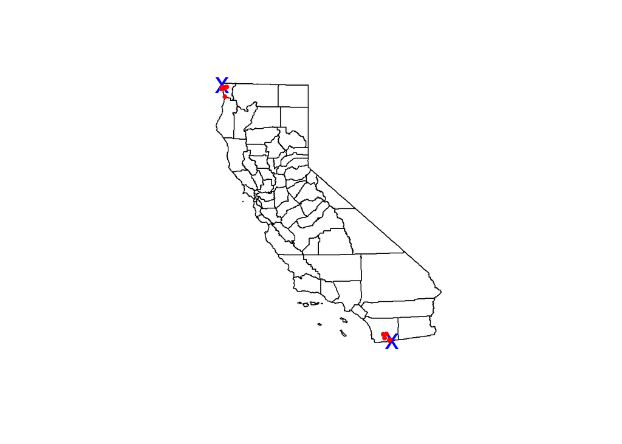

```r
##plot it
plot(cata) #plots the counties
points(cp[1, 1:2, drop=FALSE], col='blue', pch='x', cex=2) #adds an "x" to athe first county in the list
points(dta[ngb[1,], ], col='red', pch=20) #added first county's 5 nearest neighbros
points(cp[nrow(cp), 1:2, drop=FALSE], col='blue', pch='x', cex=2) #add an x to the last row oc cp (which is what nrow calculates)
points(dta[ngb[nrow(cp),], ], col='red', pch=20) # add the 5 nearest neighbors for the last row
```

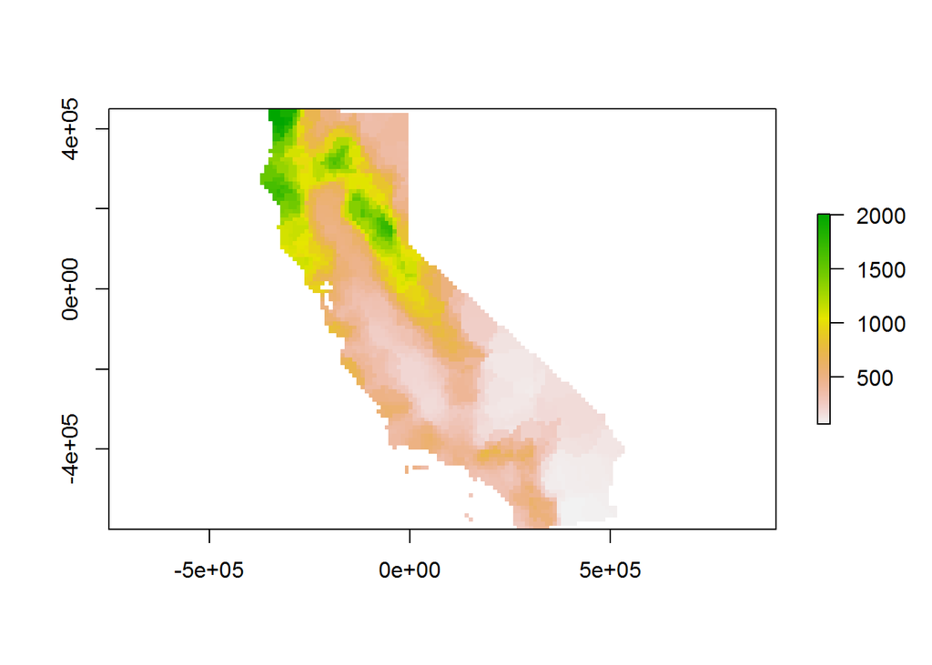

```r
##make a map
#make pairs
pairs <- cbind(rep(1:nrow(ngb), nn), as.vector(ngb))

#head(dta)

#get values for pairs and compute average
values <- dta$prec[pairs[,2]]
pn <- tapply(values, pairs[,1], mean)

#assign to new raster
nnr <- r
nnr[!is.na(vr)] <- pn
plot(nnr)
```

cross validate

```r
rr <- r
rmse <- rep(NA, 5)
for (k in 1:5) {
  test <- dta[kf == k, ]
  train <- dta[kf != k, ]
  e <- pointDistance(cp[, 1:2], train, lonlat=FALSE)
  ngb <- t(apply(e, 1, function(x) order(x)[1:nn]))
  pairs <- cbind(rep(1:nrow(ngb), nn), as.vector(ngb))
  values <- dta$prec[pairs[,2]]
  pn <- tapply(values, pairs[,1], mean)
  rr[!is.na(vr)] <- pn
  p <- extract(rr, test)
  rmse[k] <- RMSE(test$prec, p)
}
rmse
```

```
## [1] 439.6392 456.5775 516.1709 458.4795 434.5379
```

```r
## [1] 439.6392 456.5775 516.1709 458.4795 434.5379
mean(rmse)
```

```
## [1] 461.081
```

```r
## [1] 461.081
1 - (mean(rmse) / null)
```

```
## [1] -0.0591731
```

```r
## [1] -0.0591731
```

# Inverse Distance Weighted Spatial Average

Height z is a distance-weighted sum of sample values in a defined neighborhood. Nearest locations given more weight in that calculation than farther away locations. The problem with this is both distance and theh weights are assigned arbitrarily.

```r
#install.packages("gstat")
library(gstat)
#gstat makes objects that hold info for uni or multivariate geostatistical predictions (for kriging)
#argument 1, g= gstat object to add to or be created if missing; arg 2, id= identifier of new variable, if missing, n is used; arg 3, formula = defines the dependent variable, for ordinary or simple kriging use name ~1; arg 4, locations = spatial data locations
gs <- gstat(formula=prec~1, locations=dta)

#interpolate makes a rasterlayer with x,y as independent variables (bc z is dependent.) 1st argument, object = raster object; 2nd argument, model = model object
#r <- raster(cata, res=10000) raster of CA counties
#gs is gstat object of precip with lon/lat locations
idw <- interpolate(r, gs)
```

```
## [inverse distance weighted interpolation]
```

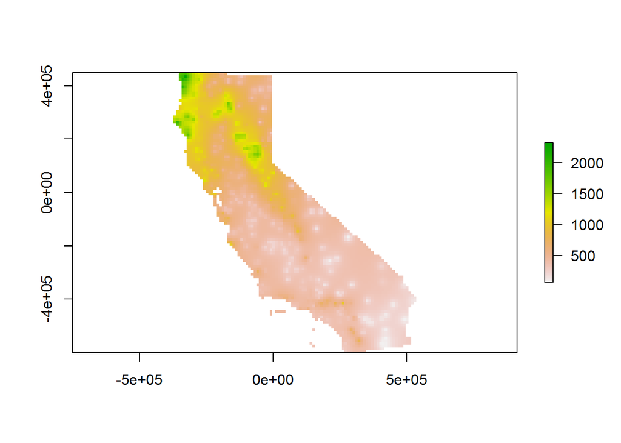

```r
## [inverse distance weighted interpolation]

idwr <- mask(idw, vr) #new raster object with the same values as idw that masks vr, the raster of voroni polygons of precip data fitted to CA counties
plot(idwr)
```

####Question 4: IDW generated rasters tend to have a noticeble artifact. What is that? The artifact is that the distance cut-off is arbitrarily assigned, and therefore, the weights for the values are as well. Results can vary depending on how steeply a drop-off in weights is coded for. Additionally, if the neighborhood is defined by distance, the density of points in neighborhoods can impact how much weight each point gets. There is not a way to control for this variation across neighborhoods. For a neighborhood with few points, each of these will have more weight and impact on the on the overall value than a neighborhood with many points.

#### Cross Validate the IDW

```r
rmse <- rep(NA, 5)
for (k in 1:5) {
  test <- dta[kf == k, ]
  train <- dta[kf != k, ]
  gs <- gstat(formula=prec~1, locations=train)
  p <- predict(gs, test)
  rmse[k] <- RMSE(test$prec, p$var1.pred)
}
```

```
## [inverse distance weighted interpolation]
## [inverse distance weighted interpolation]
## [inverse distance weighted interpolation]
## [inverse distance weighted interpolation]
## [inverse distance weighted interpolation]
```

```r
rmse
```

```
## [1] 215.3319 211.9383 190.0231 211.8308 230.1893
```

```r
## [1] 215.3319 211.9383 190.0231 211.8308 230.1893
mean(rmse)
```

```
## [1] 211.8627
```

```r
## [1] 211.8627
1 - (mean(rmse) / null)
```

```
## [1] 0.5133192
```

```r
## [1] 0.5133192
```

#### Question 5: Inspect the arguments used for and make a map of the IDW model below. What other name could you give to this method (IDW with these parameters)? Why?

```r
gs2 <- gstat(formula=prec~1, locations=dta, nmax=1, set=list(idp=1))

# prec~1 is dependent variable, locations are dta, nmax = the number of nearest observations to be used, set= list of parameters for gstat, not sure what idp is

idw2 <-interpolate(r, gs2)
```

```
## [inverse distance weighted interpolation]
```

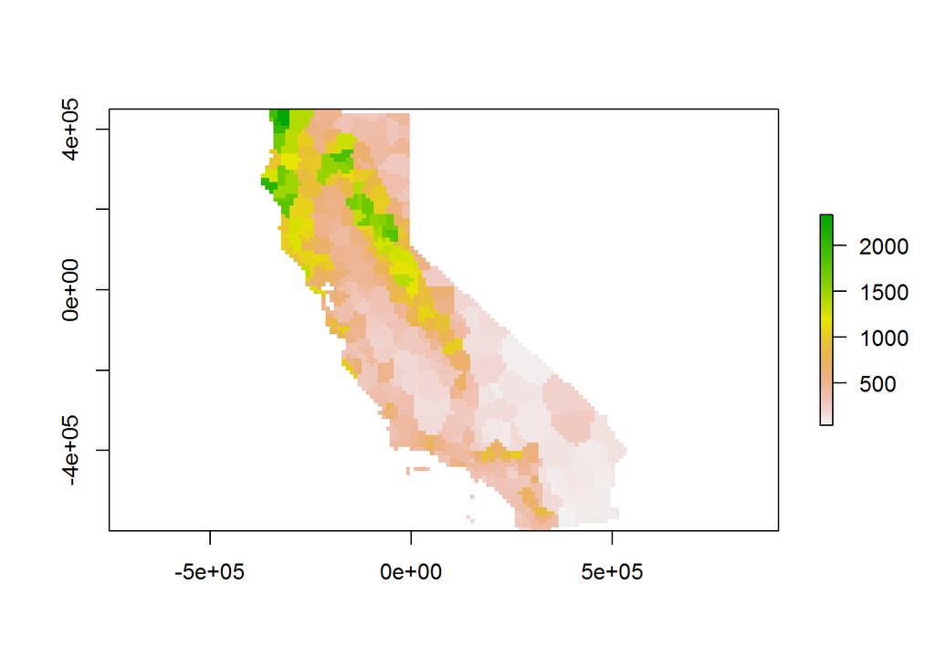

```r
## [inverse distance weighted interpolation]

idwr2 <- mask(idw2, vr) #new raster object with the same values as idw that masks vr, the raster of voroni polygons of precip data fitted to CA counties
plot(idwr2)
```

By setting nmax so only the single closest observation can be used, it seems similar to setting up a single nearest neighbor interpolation.

# Statistical Interpolation

### Data Prep

```r
datapath <- "C:/Users/ebola/Google Drive/Git/GEO200CN/data"
x <- read.csv(file.path(datapath, "airqual.csv"))
class(x)
```

```
## [1] "data.frame"
```

```r
x$OZDLYAV <- x$OZDLYAV * 1000 #OZDLYAV means ozone level parts per billion, multiplied by 1000 to make it easier to read

#make a spatialpointsdataframe, transform to teale albers, the california projection
library(sp)

coordinates(x) <- ~LONGITUDE + LATITUDE
proj4string(x) <- CRS('+proj=longlat +datum=NAD83')
TA <- CRS("+proj=aea +lat_1=34 +lat_2=40.5 +lat_0=0 +lon_0=-120 +x_0=0 +y_0=-4000000 +datum=NAD83 +units=km +ellps=GRS80")
library(rgdal)
aq <- spTransform(x, TA) #air quality data in the TA CRS
#head(aq)
#names(aq)

#make template rater to interpolate- turn the spatialpolygons df of CA into a spatial grid
cageo <- readRDS(file.path(datapath, 'counties.rds'))
catrans <- spTransform(cageo, TA)
rca <- raster(catrans)
res(rca) <- 10  # sets 10 km resolution since your CRS's units are in km
g <- as(rca, 'SpatialGrid')#CA counties as a spatial grid with the TA projection
class(g)
```

```
## [1] "SpatialGrid"
## attr(,"package")
## [1] "sp"
```

```r
#head(g)
```

### Variogram

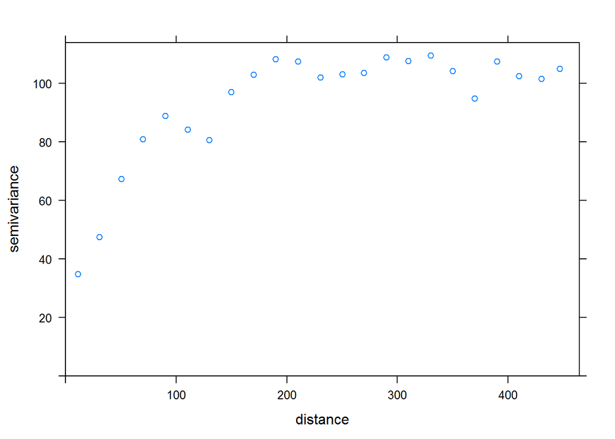

```r
gsozone <- gstat(formula=OZDLYAV~1, locations=aq)

vozone <- variogram(gsozone, width=20)
#head(vozone)
##     np      dist    gamma dir.hor dir.ver   id
## 1 1010  11.35040 34.80579       0       0 var1
## 2 1806  30.63737 47.52591       0       0 var1
## 3 2355  50.58656 67.26548       0       0 var1
## 4 2619  70.10411 80.92707       0       0 var1
## 5 2967  90.13917 88.93653       0       0 var1
## 6 3437 110.42302 84.13589       0       0 var1
plot(vozone)
```